```python
import os
import pandas as pd
import numpy  as np
import math
import matplotlib.pyplot as plt
from PIL import Image
from PIL import ImageTk
from sklearn.model_selection import train_test_split
from sklearn.neural_network import MLPClassifier
from sklearn.metrics import confusion_matrix
from sklearn.preprocessing import LabelEncoder
from pandas import DataFrame
from matplotlib import colors as mcolors
from sklearn.preprocessing import StandardScaler
import seaborn as sn
%matplotlib inline
from keras import layers
from keras.layers import Flatten, Input, Add, Dense, Activation, ZeroPadding2D, BatchNormalization, Flatten, Conv2D, AveragePooling2D, MaxPooling2D, GlobalMaxPooling2D, Dropout,MaxPool2D
from keras.models import Sequential, Model, load_model
from keras.preprocessing import image
from keras.preprocessing.image import load_img
from keras.preprocessing.image import img_to_array
from keras.applications.imagenet_utils import decode_predictions
from keras.utils import layer_utils, np_utils
from keras.utils.data_utils import get_file
from keras.applications.imagenet_utils import preprocess_input
from keras.utils.vis_utils import model_to_dot
from keras.utils import plot_model
from keras.initializers import glorot_uniform
from keras import losses
import keras.backend as K
from keras.callbacks import ModelCheckpoint
from sklearn.metrics import confusion_matrix, classification_report
import tensorflow as tf
from keras.utils.np_utils import to_categorical # convert to one-hot-encoding


import warnings
warnings.filterwarnings('ignore')
```

Tarea Número 3

# Ejercicio 1:

**[10 puntos]** Basado en el código visto en el documento de la clase sobre las convoluciones, investigue y aplique al menos 3 núcleos o filtros diferentes para la imagen `einstein.csv`. Muestre las imágenes generadas.

```python
datos = pd.read_csv("datos/einstein.csv", sep=";", decimal=".", header = None, index_col = None)
datos
```

|  | 0 | 1 | 2 | 3 | 4 | 5 | 6 | 7 | 8 | 9 | ... | 246 | 247 | 248 | 249 | 250 | 251 | 252 | 253 | 254 | 255 |
| --- | --- | --- | --- | --- | --- | --- | --- | --- | --- | --- | --- | --- | --- | --- | --- | --- | --- | --- | --- | --- | --- |
| 0 | 27 | 27 | 27 | 27 | 27 | 27 | 29 | 29 | 31 | 30 | ... | 139 | 143 | 148 | 142 | 149 | 150 | 144 | 143 | 145 | 145 |
| 1 | 27 | 27 | 27 | 27 | 27 | 27 | 29 | 29 | 31 | 30 | ... | 139 | 143 | 148 | 142 | 149 | 150 | 144 | 143 | 145 | 145 |
| 2 | 31 | 31 | 31 | 30 | 26 | 26 | 21 | 24 | 27 | 29 | ... | 143 | 147 | 141 | 148 | 153 | 150 | 148 | 143 | 143 | 143 |
| 3 | 27 | 27 | 26 | 27 | 27 | 27 | 29 | 25 | 29 | 27 | ... | 143 | 144 | 150 | 151 | 149 | 149 | 150 | 143 | 148 | 148 |
| 4 | 25 | 25 | 30 | 29 | 26 | 25 | 26 | 24 | 27 | 30 | ... | 145 | 148 | 151 | 153 | 150 | 148 | 153 | 148 | 151 | 151 |
| ... | ... | ... | ... | ... | ... | ... | ... | ... | ... | ... | ... | ... | ... | ... | ... | ... | ... | ... | ... | ... | ... |
| 251 | 104 | 104 | 104 | 104 | 124 | 114 | 104 | 99 | 105 | 101 | ... | 49 | 50 | 48 | 46 | 42 | 35 | 36 | 33 | 25 | 25 |
| 252 | 98 | 98 | 105 | 104 | 101 | 93 | 87 | 101 | 107 | 105 | ... | 48 | 42 | 42 | 39 | 37 | 33 | 35 | 30 | 24 | 24 |
| 253 | 100 | 100 | 111 | 101 | 111 | 98 | 93 | 104 | 102 | 105 | ... | 56 | 38 | 43 | 38 | 32 | 32 | 33 | 25 | 23 | 23 |
| 254 | 100 | 100 | 92 | 98 | 105 | 98 | 98 | 83 | 97 | 94 | ... | 50 | 39 | 41 | 39 | 30 | 29 | 25 | 20 | 26 | 26 |
| 255 | 100 | 100 | 92 | 98 | 105 | 98 | 98 | 83 | 97 | 94 | ... | 50 | 39 | 41 | 39 | 30 | 29 | 25 | 20 | 26 | 26 |

256 rows × 256 columns

- Identidad

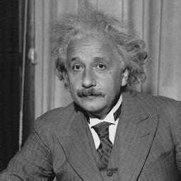

```python
km = [0, 0, 0,
      0, 1, 0,
      0, 0, 0]
k = ImageFilter.Kernel(size=(3, 3),kernel=km, scale=1)

im2 = im.filter(k)
im2
```

- Desenfoque

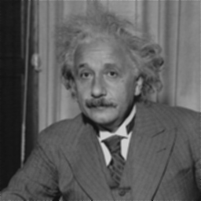

```python
km = (
    1, 1, 1,
    1, 1, 1,
    1, 1, 1
)

k = ImageFilter.Kernel(size=(3, 3),kernel=km, scale=10)

im2 = im.filter(k)
im2
```

- Enfoque

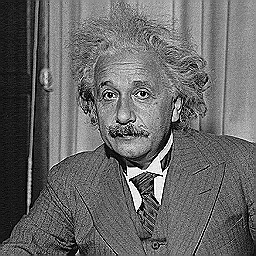

```python
km = (
    0, -1, 0,
    -1, 5, -1,
    0, -1, 0
)
k = ImageFilter.Kernel(size=(3, 3),kernel=km, scale=1)

im2 = im.filter(k)
im2
```

# Ejercicio 2:

**[15 puntos]** Para cada capa, calcule el tamaño de los mapas de características asociados (“feature mapping”) o tamaño de las matrices y el número de parámetros entrenables. La notación sigue la convención:

1. *CONV-K-N* denota una capa convolucional con *N* Filtros, cada uno de tamaño. K × K, los parámetros “padding” y “stride” serán siempre 0 y 1 respectivamente.
1. *POOL-K* indica una capa de “pooling” de tamaño *K × K* con “stride” *K* y “padding” 0.
1. *FLATTEN* denota la capa aplanada.
1. *FC-N* representa una capa completamente conectada (Fully-Connected) con *N* neuronas.

[output not shown]

# Ejercicio 3:

**[15 puntos]** Para cada capa, calcule el tamaño de los mapas de características asociados (“feature mapping”) o tamaño de las matrices y el número de parámetros entrenables. La notación sigue la convención:

1. *CONV-K-N* denota una capa convolucional con *N* Filtros, cada uno de tamaño. K × K, los parámetros “padding” y “stride” serán siempre 0 y 1 respectivamente.
1. *POOL-K* indica una capa de “pooling” de tamaño *K × K* con “stride” *K* y “padding” 0.
1. *ReLU* indica la aplicación de la función de activación *ReLU*.
1. *FLATTEN* denota la capa aplanada.
1. *FC-N* representa una capa completamente conectada (Fully-Connected) con *N* neuronas.

[output not shown]

# Ejercicio 4:

**[10 puntos]** ¿Cuáles de las siguientes considera que son funciones de activación válidas (funciones no lineales) para entrenar una red neuronal en la práctica?

1. $f(x) = -min(2,x)$ , rango $y \leq 2$
2. $f(x) = 0.9x+1$, rango $R$
3. $f(x) = min(x,0.1x)$, rango $R$
4. $ f(x) = \begin{cases} max(x,0.1x) & \text{si $x \geq 0$} \\ min(x,0.1x) & \text{si $x < 0$} \end{cases} $, rango $R$

Creo que solo la 1

# Ejercicio 5:

**[25 puntos]** Este conjunto de datos tiene 10 clases que contienen 600 imágenes cada una. Hay 500 imágenes de entrenamiento y 100 imágenes de prueba por clase. Cada imagen viene con una etiqueta `fina` (la clase a la que pertenece). El objetivo del conjunto de datos es predecir el tipo de imagen.

- Clase 0: Manzana.
- Clase 1: Pez.
- Clase 2: Bebé.
- Clase 3: Oso.
- Clase 4: Castor.
- Clase 5: Cama.
- Clase 6: Abeja.
- Clase 7: Escarabajo. • Clase 8: Bicicleta.
- Clase 9: Botella.

Realice lo siguiente:

1. Cargue las tablas de datos `imagenes_x_train.npy`, `imagenes_y_train.npy`, `imagenes_x_test.npy` y `imagenes_y_test.npy` en `Python`.

```python
x_train_original = np.load('imagenesClase/imagenes_x_train.npy')

y_train_original = np.load('imagenesClase/imagenes_y_train.npy')


x_test_original = np.load('imagenesClase/imagenes_x_test.npy')
y_test_original = np.load('imagenesClase/imagenes_y_test.npy')
```

1. Pase las tablas de las categorías (`imagenes_y_train.npy` y `imagenes_y_test.npy`) a la forma one-hot-encoding

```python
y_train = np_utils.to_categorical(y_train_original, 10)
y_test = np_utils.to_categorical(y_test_original, 10)
```

1. Imprima una imagen de la tabla imagenes `x_train.npy`.

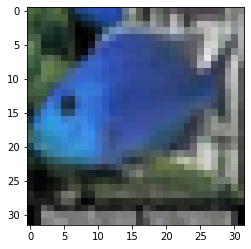

```python
imgplot = plt.imshow(x_train_original[601])
plt.show()
```

1. Normalice las imágenes de las tablas.

```python
x_train = x_train_original/255
x_test = x_test_original/255
```

1. Genere un modelo de Redes Neuronales Convolucionales. Para esto utilice al menos 2 capas de convolución 2d y 2 capas de Maxpooling, luego utilice `flatten()`, `Dropout()` y al menos 2 capas ocultas. Utilice la función de optimización `adam`, la función de costo `categorical_crossentropy` y la métrica `accuracy`.

```python
def create_simple_cnn():
    model = Sequential()
    model.add(Conv2D(32, kernel_size=(3, 3), input_shape=(32, 32, 3), activation='relu'))
    model.add(Conv2D(64, kernel_size=(3, 3), activation='relu'))
    model.add(MaxPooling2D(pool_size=(2, 2)))
    model.add(MaxPooling2D(pool_size=(2, 2)))

    model.add(Flatten())
    model.add(Dense(500, activation='relu'))
    model.add(Dropout(0.5))
    model.add(Dense(10, activation='softmax'))
    model.compile(loss='categorical_crossentropy', optimizer='adam', metrics=['acc'])

    return model

scnn_model = create_simple_cnn()
```

1. Haga un resumen del modelo.

```python
scnn_model.summary()
```

```
Model: "sequential"
_________________________________________________________________
Layer (type)                 Output Shape              Param #
=================================================================
conv2d (Conv2D)              (None, 30, 30, 32)        896
_________________________________________________________________
conv2d_1 (Conv2D)            (None, 28, 28, 64)        18496
_________________________________________________________________
max_pooling2d (MaxPooling2D) (None, 14, 14, 64)        0
_________________________________________________________________
max_pooling2d_1 (MaxPooling2 (None, 7, 7, 64)          0
_________________________________________________________________
flatten (Flatten)            (None, 3136)              0
_________________________________________________________________
dense (Dense)                (None, 500)               1568500
_________________________________________________________________
dropout (Dropout)            (None, 500)               0
_________________________________________________________________
dense_1 (Dense)              (None, 10)                5010
=================================================================
Total params: 1,592,902
Trainable params: 1,592,902
Non-trainable params: 0
_________________________________________________________________
```

1. Entrene el modelo con los siguientes parámetros `epochs=50` y `batch_size=20`. Esto puede tardar un rato.

```python
scnn=scnn_model.fit(x=x_train, y=y_train, batch_size=20, epochs=50, verbose=1, validation_data=(x_test, y_test), shuffle=True)
```

1. Utilice el método `evaluate()` para evaluar las predicciones y el error global. Establezca el valor de 0 para el parámetro `verbose` para omitir la salida en consola.

```python
test_eval = scnn_model.evaluate(x_test, y_test, verbose=0)

print('\nTest loss:', test_eval[0])
print('Test accuracy:', test_eval[1])
```

```
Test loss: 1.9396549463272095
Test accuracy: 0.7070000171661377
```

1. Obtenga las predicciones sobre la tabla de testing utilizando la función `predict()`. Genere la matriz de confusión, obtenga la precisión global y por categoría. Muestre y comente los resultados.

```python
scnn_pred = scnn_model.predict(x_test, batch_size=32, verbose=1)
scnn_predicted = np.argmax(scnn_pred, axis=1)
```

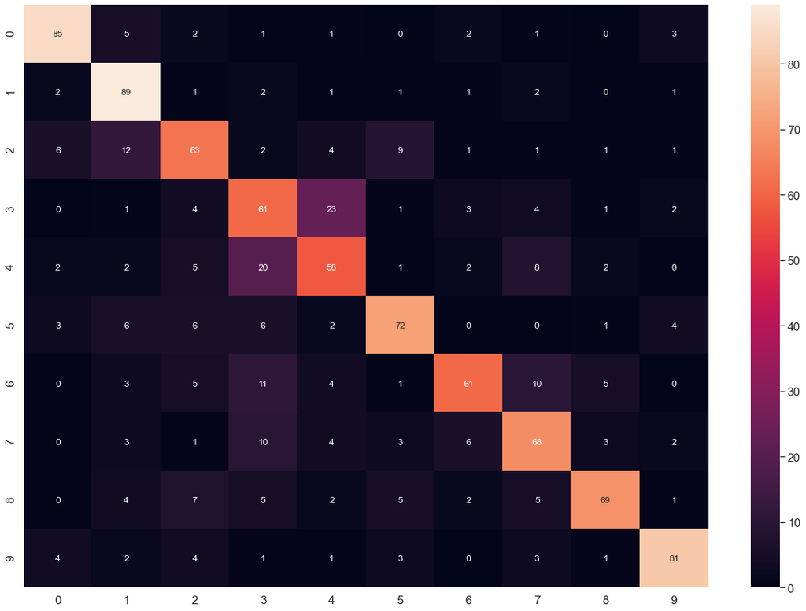

```python
scnn_cm = confusion_matrix(np.argmax(y_test, axis=1), scnn_predicted)

# Visualiamos la matriz de confusión
scnn_df_cm = pd.DataFrame(scnn_cm, range(10), range(10))
plt.figure(figsize = (20,14))
sn.set(font_scale=1.4) #for label size
sn.heatmap(scnn_df_cm, annot=True, annot_kws={"size": 12}) # font size
plt.show()
```

```python
scnn_report = classification_report(np.argmax(y_test, axis=1), scnn_predicted)
print(scnn_report)
```

```
              precision    recall  f1-score   support

           0       0.83      0.85      0.84       100
           1       0.70      0.89      0.78       100
           2       0.64      0.63      0.64       100
           3       0.51      0.61      0.56       100
           4       0.58      0.58      0.58       100
           5       0.75      0.72      0.73       100
           6       0.78      0.61      0.69       100
           7       0.67      0.68      0.67       100
           8       0.83      0.69      0.75       100
           9       0.85      0.81      0.83       100

    accuracy                           0.71      1000
   macro avg       0.72      0.71      0.71      1000
weighted avg       0.72      0.71      0.71      1000
```

1. Tome 3 imágenes de la tabla de testing, muéstrelas y realice una predicción con el modelo generado.

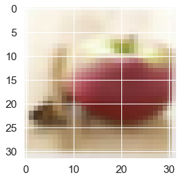

```
class for image 1: 0
predicted:         0
```

```python
imgplot = plt.imshow(x_train_original[0])
plt.show()
print('class for image 1: ' + str(np.argmax(y_test[0])))
print('predicted:         ' + str(scnn_predicted[0]))
```

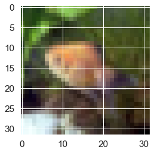

```
class for image 1: 9
predicted:         3
```

```python
imgplot = plt.imshow(x_train_original[999])
plt.show()
print('class for image 1: ' + str(np.argmax(y_test[999])))
print('predicted:         ' + str(scnn_predicted[999]))
```

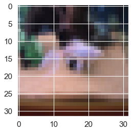

```
class for image 612: 6
predicted:         6
```

```python
imgplot = plt.imshow(x_train_original[612])
plt.show()
print('class for image 612: ' + str(np.argmax(y_test[612])))
print('predicted:         ' + str(scnn_predicted[612]))
```

# Ejercicio 6:

**[25 puntos]** [25 puntos] En este ejercicio vamos a usar las tablas de datos `ZipDataTestCod.csv`,`ZipDataTrainCod.csv`, la primera columna guarda la información de tipo de dígito es: un número del 0 al 9, mientras que las otras 256 columnas guardan la información de cada pixel, para una imagen de 16x16 de un solo canal.

Para esto realice lo siguiente:

1. Cargue las tablas de datos `ZipDataTestCod.csv` `ZipDataTrainCod.csv` en `Python`.

```python
train = pd.read_csv('datos/ZipDataTestCod.csv',delimiter=";",decimal=".")
test = pd.read_csv('datos/ZipDataTrainCod.csv',delimiter=";",decimal="." )
```

1. Genere las tablas de las categorías (`Y_train` y `Y_test`) y paselas a la forma **one-hot- encoding**

```python
y_train = train["Numero"]
y_test = test["Numero"]

# integer-encode strings
y_train = np.array(y_train)
y_test = np.array(y_test)

label_encoder = LabelEncoder()

y_train = label_encoder.fit_transform(y_train)
y_test = label_encoder.fit_transform(y_test)


y_train = to_categorical(y_train, num_classes = 10)
y_test = to_categorical(y_test, num_classes = 10)

y_train
```

```
array([[0., 0., 0., ..., 0., 0., 0.],
       [0., 0., 0., ..., 0., 0., 0.],
       [0., 0., 0., ..., 0., 1., 0.],
       ...,
       [0., 0., 1., ..., 0., 0., 0.],
       [1., 0., 0., ..., 0., 0., 0.],
       [0., 0., 0., ..., 0., 0., 1.]], dtype=float32)
```

1. Genere las tablas de las imágenes (`X_train` y `X_test`) realizando un `reshape(-1, 16,16,1)` con `numpy` y seguidamente normalice dichas tablas.

```python
X_train = train.drop(labels = ["Numero"],axis = 1)
X_test = test.drop(labels = ["Numero"],axis = 1)


scaler = StandardScaler()
X_train = scaler.fit_transform(X_train)
X_test = scaler.fit_transform(X_test)


X_train = X_train.reshape(-1,16,16,1)
X_test = X_test.reshape(-1,16,16,1)
```

1. Imprima una imagen de la tabla `X_train`.

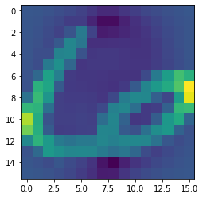

```python
imgplot = plt.imshow(X_train[1])
plt.show()
```

1. Genere un modelo de Redes Neuronales Convolucionales. Para esto utilice 2 capas de convolución 2d y 2 capas de `Maxpooling`, luego utilice `flatten()`, `Dropout()` y al menos 2 capas ocultas. Utilice la función de optimización `RMSprop`, la función de costo `categorical_crossentropy` y la métrica `accuracy`.

```python
def create_simple_cnn():

    model = Sequential()

    model.add(Conv2D(filters = 32, kernel_size = (5,5),padding = 'Same',
                 activation ='relu', input_shape = (16,16,1)))
    model.add(Conv2D(filters = 32, kernel_size = (5,5),padding = 'Same',
                 activation ='relu'))
    model.add(MaxPool2D(pool_size=(2,2)))
    model.add(MaxPool2D(pool_size=(2,2)))
    model.add(Dropout(0.25))




    model.add(Flatten())
    model.add(Dense(256, activation = "relu"))
    model.add(Dropout(0.5))
    model.add(Dense(10, activation = "softmax"))

    # Compile the model
    model.compile(optimizer = 'RMSprop' , loss = "categorical_crossentropy", metrics=["accuracy"])

    return model


cnn_model = create_simple_cnn()
```

1. Haga un resumen del modelo.

```python
cnn_model.summary()
```

```
Model: "sequential_3"
_________________________________________________________________
Layer (type)                 Output Shape              Param #
=================================================================
conv2d_6 (Conv2D)            (None, 16, 16, 32)        832
_________________________________________________________________
conv2d_7 (Conv2D)            (None, 16, 16, 32)        25632
_________________________________________________________________
max_pooling2d_6 (MaxPooling2 (None, 8, 8, 32)          0
_________________________________________________________________
max_pooling2d_7 (MaxPooling2 (None, 4, 4, 32)          0
_________________________________________________________________
dropout_6 (Dropout)          (None, 4, 4, 32)          0
_________________________________________________________________
flatten_3 (Flatten)          (None, 512)               0
_________________________________________________________________
dense_6 (Dense)              (None, 256)               131328
_________________________________________________________________
dropout_7 (Dropout)          (None, 256)               0
_________________________________________________________________
dense_7 (Dense)              (None, 10)                2570
=================================================================
Total params: 160,362
Trainable params: 160,362
Non-trainable params: 0
_________________________________________________________________
```

```python
cnn=cnn_model.fit(x=X_train, y=y_train, batch_size=60, epochs=18, verbose=1, validation_data=(X_test, y_test), shuffle=True)
```

1. Utilice el método `evaluate()` para evaluar las predicciones y el error global. Establezca el valor de 0 para el parámetro `verbose` para omitir la salida en consola.

```python
test_eval = cnn_model.evaluate(X_test, y_test, verbose=0)

print('\nTest loss:', test_eval[0])
print('Test accuracy:', test_eval[1])
```

```
Test loss: 0.0709691271185875
Test accuracy: 0.980523943901062
```

1. Obtenga las predicciones sobre la tabla de testing utilizando la función `predict()`. Genere la matriz de confusión, obtenga la precisión global y por categoría. Muestre y comente los resultados.

```python
cnn_pred = cnn_model.predict(X_test, batch_size=86, verbose=1)
cnn_predicted = np.argmax(cnn_pred, axis=1)
```

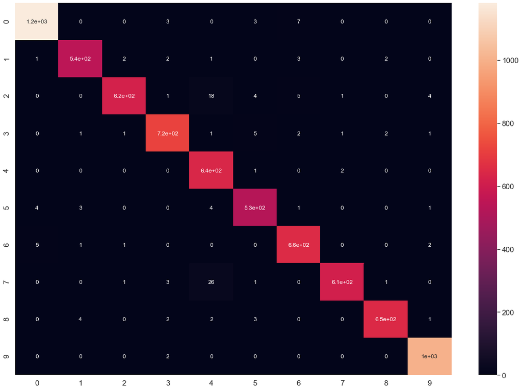

```python
cnn_cm = confusion_matrix(np.argmax(y_test, axis=1), cnn_predicted)
cnn_df_cm = pd.DataFrame(cnn_cm, range(10), range(10))
plt.figure(figsize = (20,14))
sn.set(font_scale=1.4) #for label size
sn.heatmap(cnn_df_cm, annot=True, annot_kws={"size": 12}) # font size
plt.show()
```

```python
cnn_report = classification_report(np.argmax(y_test, axis=1), cnn_predicted)
print(cnn_report)
```

```
              precision    recall  f1-score   support

           0       0.99      0.99      0.99      1194
           1       0.98      0.98      0.98       556
           2       0.99      0.95      0.97       652
           3       0.98      0.98      0.98       731
           4       0.92      1.00      0.96       644
           5       0.97      0.98      0.97       542
           6       0.97      0.99      0.98       664
           7       0.99      0.95      0.97       645
           8       0.99      0.98      0.99       658
           9       0.99      1.00      0.99      1005

    accuracy                           0.98      7291
   macro avg       0.98      0.98      0.98      7291
weighted avg       0.98      0.98      0.98      7291
```

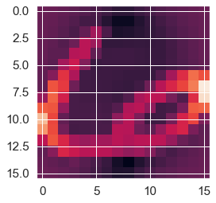

```
class for image 1: 6
predicted:         6
```

```python
# visualizando algunos resultados

imgplot = plt.imshow(X_train[1])
plt.show()
print('class for image 1: ' + str(np.argmax(y_test[0])))
print('predicted:         ' + str(cnn_predicted[0]))
```

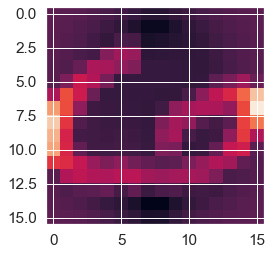

```
class for image 2: 7
predicted:         7
```

```python
imgplot = plt.imshow(X_train[3])
plt.show()
print('class for image 2: ' + str(np.argmax(y_test[3])))
print('predicted:         ' + str(cnn_predicted[3]))
```